# PECMM020

# Task 3

### checking the correlation

```r
cor <- cor(vessel$Beam,vessel$Length)
cor
```

```
## [1] 0.9321226
```

The correlation coefficient is greater than 0.05 p-value. It shows a strong and positive association between them.It is suitable.

#### Prediciting the Beam

```r
lm.output<-lm(formula= Beam~Length,data=vessel)
summary(lm.output)
```

```
##
## Call:
## lm(formula = Beam ~ Length, data = vessel)
##
## Residuals:
##     Min      1Q  Median      3Q     Max
## -9.0691 -1.9670 -0.2639  1.8466  8.8263
##
## Coefficients:
##             Estimate Std. Error t value Pr(>|t|)
## (Intercept) 4.933085   0.313180   15.75   <2e-16 ***
## Length      0.123537   0.001569   78.75   <2e-16 ***
## ---
## Signif. codes:  0 '***' 0.001 '**' 0.01 '*' 0.05 '.' 0.1 ' ' 1
##
## Residual standard error: 3.358 on 936 degrees of freedom
## Multiple R-squared:  0.8689, Adjusted R-squared:  0.8687
## F-statistic:  6201 on 1 and 936 DF,  p-value: < 2.2e-16
```

The linear equation for Beam = 4.933085 + 0.123537*Length

The coefficient of determination is Multiple R-squared: 0.8689

#### Performing Further checks for suitability

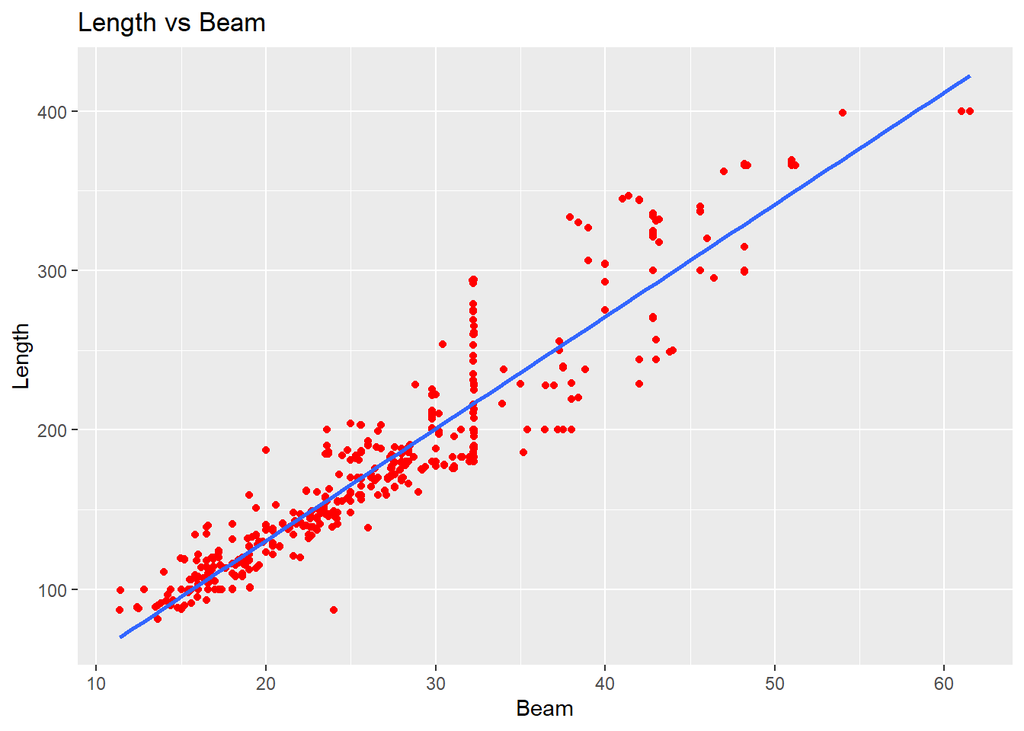

```r
p <- ggplot(vessel,aes(x=Beam,y=Length))
p <- p + geom_point(colour= "red" ) + stat_smooth(method="lm",formual= y~x,  se=F)
p <- p + labs(title = "Length vs Beam", x ="Beam", y ="Length")
p
```

The points are close to the theoretical lines. The points are more clustered at the early stage of the Length and Beam and became few as the Beam increases with the Length. The data shows a positive association. Therefore I would say it is suitable.